"Real world data are messy"

# An Introduction to Exploratory Data Analysis (EDA)

by Faathir Chikal Asyuraa

Apasih yang dimaksud dengan Exploratory Data Analysis (EDA)? Tidak ada definisi baku untuk EDA, EDA adalah serangkaian langkah langkah untuk mengenal lebih jauh data yang anda teliti  
Proses ini pun cenderung iteratif dan sangat variatif tergantung jenis data yang anda teliti  
Sehingga, tidak ada langkah baku atau alur yang harus dipatuhi  
Tapi, berikut ini adalah contoh contoh ide yang bisa dilakukan untuk memulai EDA

- Pertanyaan apa yang anda mau teliti? Adakah hal yang ingin diketahui? Apa yang ingin dibuktikan?
- Tipe data apa yang anda miliki? Bagaimana cara menghandle tipe data tersebut?
- Apakah ada data yang missing? jika ada, apa yang mesti dilakukan?
- Apakah ada outlier atau noise? apa yang mesti dilakukan?
- Apakah ada variabel yang bisa ditambahkan? atau adakah variabel yang bisa dibuang?

Ada juga yang melakukan EDA dengan mendefinisikan bagian bagian kerja  
Seperti

- Data Cleansing
- Penemuan masalah/pertanyaan
- Mengkomunikasikan hasil dengan Visualisasi

Dan masih banyak langkah langkah lainnya, intinya, eksplor seluas mungkin data anda, kenali data anda, sebelum dilanjutkan ke metode atau model yang cukup kompleks

[figure not shown]

Untuk workshop kali ini, akan membahas dataset film tmdb  
dataset dapat dilihat di https://www.kaggle.com/tmdb/tmdb-movie-metadata/download

[figure not shown]

Package yang digunakan

```python
#Necessary package
import pandas as pd
import numpy as np
import matplotlib.pyplot as plt
import seaborn as sns
from datetime import datetime
import ast, json
```

```python
credits = pd.read_csv('Dataset/tmdb-movie-metadata/tmdb_5000_credits.csv')
movies = pd.read_csv('Dataset/tmdb-movie-metadata/tmdb_5000_movies.csv')
```

# Data Cleansing

```python
credits.sample(5)
```

|  | movie_id | title | cast | crew |
| --- | --- | --- | --- | --- |
| 2857 | 14976 | Rachel Getting Married | [{"cast_id": 1, "character": "Kym", "credit_id... | [{"credit_id": "52fe462c9251416c7506fa0d", "de... |
| 1711 | 2832 | Identity | [{"cast_id": 7, "character": "Ed", "credit_id"... | [{"credit_id": "589fd370c3a3684e89000248", "de... |
| 1001 | 15268 | Street Fighter: The Legend of Chun-Li | [{"cast_id": 1, "character": "Chun-Li", "credi... | [{"credit_id": "52fe46499251416c75073839", "de... |
| 2427 | 16112 | The Adventures of Elmo in Grouchland | [{"cast_id": 1004, "character": "Elmo / Grouch... | [{"credit_id": "56b4fccbc3a36806ea0057e6", "de... |
| 189 | 86834 | Noah | [{"cast_id": 4, "character": "Noah", "credit_i... | [{"credit_id": "53d8b3dec3a3682c43001c39", "de... |

```python
movies.sample(5)
```

|  | budget | genres | homepage | id | keywords | original_language | original_title | overview | popularity | production_companies | production_countries | release_date | revenue | runtime | spoken_languages | status | tagline | title | vote_average | vote_count |
| --- | --- | --- | --- | --- | --- | --- | --- | --- | --- | --- | --- | --- | --- | --- | --- | --- | --- | --- | --- | --- |
| 4233 | 0 | [{"id": 53, "name": "Thriller"}, {"id": 28, "n... | NaN | 323271 | [] | en | Unsullied | When car trouble strands track star Reagan Far... | 0.061240 | [] | [] | 2015-08-28 | 0 | 93.0 | [{"iso_639_1": "en", "name": "English"}] | Released | The Hunt Is On | Unsullied | 3.0 | 1 |
| 2999 | 20000000 | [{"id": 35, "name": "Comedy"}] | NaN | 10426 | [{"id": 5369, "name": "guard"}, {"id": 6490, "... | en | Friday After Next | Craig and Day Day have finally moved out of th... | 7.499639 | [{"name": "New Line Cinema", "id": 12}] | [{"iso_3166_1": "US", "name": "United States o... | 2002-11-22 | 33526835 | 85.0 | [{"iso_639_1": "en", "name": "English"}, {"iso... | Released | The party's back in the 'hood! | Friday After Next | 6.0 | 100 |
| 2226 | 0 | [{"id": 10751, "name": "Family"}] | http://www.doogalmovie.com/ | 24432 | [] | en | Doogal | This is the story of Doogal, an adorable candy... | 1.682839 | [] | [{"iso_3166_1": "FR", "name": "France"}, {"iso... | 2006-02-24 | 0 | 85.0 | [{"iso_639_1": "en", "name": "English"}] | Released | Things are about to get hairy. | Doogal | 3.2 | 18 |
| 3601 | 5000000 | [{"id": 27, "name": "Horror"}, {"id": 9648, "n... | NaN | 24913 | [{"id": 2041, "name": "island"}, {"id": 8508, ... | en | April Fool's Day | A group of eight college friends gather togeth... | 8.190888 | [{"name": "Paramount Pictures", "id": 4}, {"na... | [{"iso_3166_1": "CA", "name": "Canada"}, {"iso... | 1986-03-27 | 0 | 89.0 | [{"iso_639_1": "en", "name": "English"}] | Released | Childish pranks turn into a bloody battle for ... | April Fool's Day | 5.8 | 73 |
| 3558 | 4900000 | [{"id": 27, "name": "Horror"}, {"id": 53, "nam... | http://www.lightsoutmovie.com/ | 345911 | [{"id": 236, "name": "suicide"}, {"id": 3762, ... | en | Lights Out | When Rebecca left home, she thought she left h... | 48.170508 | [{"name": "New Line Productions", "id": 8781},... | [{"iso_3166_1": "US", "name": "United States o... | 2016-07-21 | 44107032 | 81.0 | [{"iso_639_1": "en", "name": "English"}] | Released | NaN | Lights Out | 6.3 | 1129 |

# Join table

Ada beberapa tipe join yang bisa digunakan, ada

- Inner Join
- Left Join / Right Join
- Outer Join
- Anti Join

```python
# merging the two files
movies_df = pd.merge(movies, credits, left_on ='id', right_on='movie_id', how='left', suffixes=('', '_y'))

movies_df.sample(5)
```

|  | budget | genres | homepage | id | keywords | original_language | original_title | overview | popularity | production_companies | ... | spoken_languages | status | tagline | title | vote_average | vote_count | movie_id | title_y | cast | crew |
| --- | --- | --- | --- | --- | --- | --- | --- | --- | --- | --- | --- | --- | --- | --- | --- | --- | --- | --- | --- | --- | --- |
| 849 | 55000000 | [{"id": 80, "name": "Crime"}, {"id": 18, "name... | http://www.changelingmovie.net | 3580 | [{"id": 417, "name": "corruption"}, {"id": 456... | en | Changeling | Christine Collins is overjoyed when her kidnap... | 27.509160 | [{"name": "Imagine Entertainment", "id": 23}, ... | ... | [{"iso_639_1": "en", "name": "English"}] | Released | To find her son, she did what no one else dared. | Changeling | 7.3 | 1131 | 3580 | Changeling | [{"cast_id": 6, "character": "Christine Collin... | [{"credit_id": "52fe439ec3a36847f8062297", "de... |
| 4463 | 0 | [{"id": 35, "name": "Comedy"}] | http://www.notcoolthemovie.com/ | 292483 | [{"id": 572, "name": "sex"}, {"id": 4543, "nam... | en | Not Cool | NOT COOL follows former prom king and college ... | 1.186971 | [{"name": "Steeltown Entertainment", "id": 338... | ... | [{"iso_639_1": "en", "name": "English"}] | Released | NaN | Not Cool | 3.7 | 25 | 292483 | Not Cool | [{"cast_id": 0, "character": "Scott", "credit_... | [{"credit_id": "54225d19c3a368086e000b0f", "de... |
| 2984 | 6000000 | [{"id": 18, "name": "Drama"}, {"id": 35, "name... | NaN | 16781 | [{"id": 9888, "name": "spanking"}, {"id": 1018... | en | Madea's Family Reunion | Based upon Tyler Perry's acclaimed stage produ... | 5.882208 | [{"name": "Lions Gate Films", "id": 35}] | ... | [{"iso_639_1": "en", "name": "English"}, {"iso... | Released | NaN | Madea's Family Reunion | 6.0 | 77 | 16781 | Madea's Family Reunion | [{"cast_id": 1, "character": "Madea / Brian / ... | [{"credit_id": "52fe46eb9251416c75087e49", "de... |
| 1499 | 32500000 | [{"id": 35, "name": "Comedy"}, {"id": 10749, "... | http://www.bridesmaidsmovie.com/ | 55721 | [{"id": 271, "name": "competition"}, {"id": 93... | en | Bridesmaids | Annie’s life is a mess. But when she finds out... | 17.107065 | [{"name": "Universal Pictures", "id": 33}, {"n... | ... | [{"iso_639_1": "en", "name": "English"}] | Released | Save the date | Bridesmaids | 6.5 | 1661 | 55721 | Bridesmaids | [{"cast_id": 4, "character": "Annie", "credit_... | [{"credit_id": "5674a1ea92514179d7000bea", "de... |
| 626 | 66000000 | [{"id": 9648, "name": "Mystery"}, {"id": 878, ... | NaN | 846 | [{"id": 258, "name": "bomb"}, {"id": 720, "nam... | en | The X Files | Mulder and Scully, now taken off the FBI's X F... | 18.599910 | [{"name": "Twentieth Century Fox Film Corporat... | ... | [{"iso_639_1": "en", "name": "English"}] | Released | Fight the Future | The X Files | 6.6 | 488 | 846 | The X Files | [{"cast_id": 16, "character": "Agent Fox Mulde... | [{"credit_id": "52fe4281c3a36847f802416f", "de... |

5 rows × 24 columns

Perlu ga sih semua kolom ini? apakah ada yang bisa dibuang? coba di cek kolom apa yang tidak begitu memberikan informasi

```python
#Ada apa saja kolomnya?
movies_df.columns
```

```
Index(['budget', 'genres', 'homepage', 'id', 'keywords', 'original_language',
       'original_title', 'overview', 'popularity', 'production_companies',
       'production_countries', 'release_date', 'revenue', 'runtime',
       'spoken_languages', 'status', 'tagline', 'title', 'vote_average',
       'vote_count', 'movie_id', 'title_y', 'cast', 'crew'],
      dtype='object')
```

```python
del_col_list = ['id','movie_id','keywords', 'homepage', 'status', 'tagline', 'original_language','overview', 'production_companies', 'original_title', 'title_y']

movies_df = movies_df.drop(del_col_list, axis=1)
movies_df.sample(5)
```

|  | budget | genres | popularity | production_countries | release_date | revenue | runtime | spoken_languages | title | vote_average | vote_count | cast | crew |
| --- | --- | --- | --- | --- | --- | --- | --- | --- | --- | --- | --- | --- | --- |
| 4248 | 1500000 | [{"id": 27, "name": "Horror"}, {"id": 53, "nam... | 14.504326 | [{"iso_3166_1": "CA", "name": "Canada"}, {"iso... | 2012-09-10 | 1165882 | 101.0 | [{"iso_639_1": "en", "name": "English"}] | The Lords of Salem | 5.1 | 242 | [{"cast_id": 4, "character": "Heidi Hawthrone"... | [{"credit_id": "59493b389251413fbb054f4f", "de... |
| 4056 | 0 | [{"id": 53, "name": "Thriller"}, {"id": 10749,... | 1.532518 | [{"iso_3166_1": "US", "name": "United States o... | 2008-06-13 | 0 | 90.0 | [{"iso_639_1": "en", "name": "English"}] | Impact Point | 5.7 | 5 | [{"cast_id": 1, "character": "Holden", "credit... | [{"credit_id": "533ea6e4c3a36813830012a6", "de... |
| 2068 | 9000000 | [{"id": 35, "name": "Comedy"}, {"id": 18, "nam... | 20.410354 | [{"iso_3166_1": "GB", "name": "United Kingdom"}] | 2007-02-09 | 46 | 90.0 | [{"iso_639_1": "en", "name": "English"}] | Death at a Funeral | 6.9 | 497 | [{"cast_id": 4, "character": "Daniel", "credit... | [{"credit_id": "52fe4340c3a36847f8045d0d", "de... |
| 2232 | 0 | [{"id": 35, "name": "Comedy"}, {"id": 18, "nam... | 8.628519 | [{"iso_3166_1": "GB", "name": "United Kingdom"... | 1999-09-03 | 0 | 160.0 | [{"iso_639_1": "en", "name": "English"}, {"iso... | Topsy-Turvy | 6.7 | 41 | [{"cast_id": 3, "character": "Sir Arthur Sulli... | [{"credit_id": "5544e843925141586500463a", "de... |
| 1971 | 24000000 | [{"id": 35, "name": "Comedy"}, {"id": 80, "nam... | 3.572339 | [{"iso_3166_1": "DE", "name": "Germany"}, {"is... | 2000-09-08 | 0 | 108.0 | [{"iso_639_1": "es", "name": "Espa\u00f1ol"}, ... | Nurse Betty | 5.9 | 111 | [{"cast_id": 1, "character": "Betty Sizemore",... | [{"credit_id": "52fe43789251416c75011973", "de... |

Format apa yang digunakan di kolom ke 2 (genres)?  
Format tersebut adalah format json, yang merupakan list dari dictionaries

## Bagaimana cara membaca json?

```python
#Cell kosong untuk eksperimen
```

```python
def parse_col_json(column, key):
    """
    Args:
        column: string
            name of the column to be processed.
        key: string
            name of the dictionary key which needs to be extracted
    """
    for index,i in zip(movies_df.index,movies_df[column].apply(json.loads)):
        list1=[]
        for j in range(len(i)):
            list1.append((i[j][key]))# the key 'name' contains the name of the genre
        movies_df.loc[index,column]=str(list1)
```

```python
parse_col_json('genres', 'name')
parse_col_json('spoken_languages', 'name')
parse_col_json('cast', 'name')
parse_col_json('production_countries', 'name')

movies_df.head()
```

|  | budget | genres | popularity | production_countries | release_date | revenue | runtime | spoken_languages | title | vote_average | vote_count | cast | crew |
| --- | --- | --- | --- | --- | --- | --- | --- | --- | --- | --- | --- | --- | --- |
| 0 | 237000000 | ['Action', 'Adventure', 'Fantasy', 'Science Fi... | 150.437577 | ['United States of America', 'United Kingdom'] | 2009-12-10 | 2787965087 | 162.0 | ['English', 'Español'] | Avatar | 7.2 | 11800 | ['Sam Worthington', 'Zoe Saldana', 'Sigourney ... | [{"credit_id": "52fe48009251416c750aca23", "de... |
| 1 | 300000000 | ['Adventure', 'Fantasy', 'Action'] | 139.082615 | ['United States of America'] | 2007-05-19 | 961000000 | 169.0 | ['English'] | Pirates of the Caribbean: At World's End | 6.9 | 4500 | ['Johnny Depp', 'Orlando Bloom', 'Keira Knight... | [{"credit_id": "52fe4232c3a36847f800b579", "de... |
| 2 | 245000000 | ['Action', 'Adventure', 'Crime'] | 107.376788 | ['United Kingdom', 'United States of America'] | 2015-10-26 | 880674609 | 148.0 | ['Français', 'English', 'Español', 'Italiano',... | Spectre | 6.3 | 4466 | ['Daniel Craig', 'Christoph Waltz', 'Léa Seydo... | [{"credit_id": "54805967c3a36829b5002c41", "de... |
| 3 | 250000000 | ['Action', 'Crime', 'Drama', 'Thriller'] | 112.312950 | ['United States of America'] | 2012-07-16 | 1084939099 | 165.0 | ['English'] | The Dark Knight Rises | 7.6 | 9106 | ['Christian Bale', 'Michael Caine', 'Gary Oldm... | [{"credit_id": "52fe4781c3a36847f81398c3", "de... |
| 4 | 260000000 | ['Action', 'Adventure', 'Science Fiction'] | 43.926995 | ['United States of America'] | 2012-03-07 | 284139100 | 132.0 | ['English'] | John Carter | 6.1 | 2124 | ['Taylor Kitsch', 'Lynn Collins', 'Samantha Mo... | [{"credit_id": "52fe479ac3a36847f813eaa3", "de... |

```python
# Drop data yang duplikat (jika ada)
print(movies_df.shape)
movies_df = movies_df.drop_duplicates(keep='first')
print(movies_df.shape)
```

```
(4803, 13)
(4803, 13)
```

# Overview dari data, dan sanity check

```python
movies_df.describe()
#movies_df.describe(include='all')
```

|  | budget | popularity | revenue | runtime | vote_average | vote_count |
| --- | --- | --- | --- | --- | --- | --- |
| count | 4.803000e+03 | 4803.000000 | 4.803000e+03 | 4801.000000 | 4803.000000 | 4803.000000 |
| mean | 2.904504e+07 | 21.492301 | 8.226064e+07 | 106.875859 | 6.092172 | 690.217989 |
| std | 4.072239e+07 | 31.816650 | 1.628571e+08 | 22.611935 | 1.194612 | 1234.585891 |
| min | 0.000000e+00 | 0.000000 | 0.000000e+00 | 0.000000 | 0.000000 | 0.000000 |
| 25% | 7.900000e+05 | 4.668070 | 0.000000e+00 | 94.000000 | 5.600000 | 54.000000 |
| 50% | 1.500000e+07 | 12.921594 | 1.917000e+07 | 103.000000 | 6.200000 | 235.000000 |
| 75% | 4.000000e+07 | 28.313505 | 9.291719e+07 | 118.000000 | 6.800000 | 737.000000 |
| max | 3.800000e+08 | 875.581305 | 2.787965e+09 | 338.000000 | 10.000000 | 13752.000000 |

Budget, revenue, runtime. punya minimum value 0, apakah mungkin?

```python
cols = ['budget','revenue','runtime']
movies_df[cols] = movies_df[cols].replace(0, np.nan)

# drop apa nggak 'na' nya?
movies_df.dropna(subset=cols, inplace=True)
movies_df.shape
```

```
(3229, 13)
```

Perlu fitur/variabel baru kah? misal, ada ga sih keuntungan film yang berkali kali lipat, misal 100 kali lipat dari budget yang dibuat?  
Bisa, mari kita buat fiturnya

```python
movies_df['profit']=movies_df['revenue']-movies_df['budget']
```

```python
movies_df['profit_percentage']=(movies['revenue']-movies['budget'])/movies['budget']
```

```python
# Changing the release_date column to DateTime column

movies_df.release_date = pd.to_datetime(movies_df['release_date'])
movies_df.head()

movies_df['release_year'] = movies_df['release_date'].dt.year
movies_df.head()
```

|  | budget | genres | popularity | production_countries | release_date | revenue | runtime | spoken_languages | title | vote_average | vote_count | cast | crew | profit | profit_percentage | release_year |
| --- | --- | --- | --- | --- | --- | --- | --- | --- | --- | --- | --- | --- | --- | --- | --- | --- |
| 0 | 237000000.0 | ['Action', 'Adventure', 'Fantasy', 'Science Fi... | 150.437577 | ['United States of America', 'United Kingdom'] | 2009-12-10 | 2.787965e+09 | 162.0 | ['English', 'Español'] | Avatar | 7.2 | 11800 | ['Sam Worthington', 'Zoe Saldana', 'Sigourney ... | [{"credit_id": "52fe48009251416c750aca23", "de... | 2.550965e+09 | 10.763566 | 2009 |
| 1 | 300000000.0 | ['Adventure', 'Fantasy', 'Action'] | 139.082615 | ['United States of America'] | 2007-05-19 | 9.610000e+08 | 169.0 | ['English'] | Pirates of the Caribbean: At World's End | 6.9 | 4500 | ['Johnny Depp', 'Orlando Bloom', 'Keira Knight... | [{"credit_id": "52fe4232c3a36847f800b579", "de... | 6.610000e+08 | 2.203333 | 2007 |
| 2 | 245000000.0 | ['Action', 'Adventure', 'Crime'] | 107.376788 | ['United Kingdom', 'United States of America'] | 2015-10-26 | 8.806746e+08 | 148.0 | ['Français', 'English', 'Español', 'Italiano',... | Spectre | 6.3 | 4466 | ['Daniel Craig', 'Christoph Waltz', 'Léa Seydo... | [{"credit_id": "54805967c3a36829b5002c41", "de... | 6.356746e+08 | 2.594590 | 2015 |
| 3 | 250000000.0 | ['Action', 'Crime', 'Drama', 'Thriller'] | 112.312950 | ['United States of America'] | 2012-07-16 | 1.084939e+09 | 165.0 | ['English'] | The Dark Knight Rises | 7.6 | 9106 | ['Christian Bale', 'Michael Caine', 'Gary Oldm... | [{"credit_id": "52fe4781c3a36847f81398c3", "de... | 8.349391e+08 | 3.339756 | 2012 |
| 4 | 260000000.0 | ['Action', 'Adventure', 'Science Fiction'] | 43.926995 | ['United States of America'] | 2012-03-07 | 2.841391e+08 | 132.0 | ['English'] | John Carter | 6.1 | 2124 | ['Taylor Kitsch', 'Lynn Collins', 'Samantha Mo... | [{"credit_id": "52fe479ac3a36847f813eaa3", "de... | 2.413910e+07 | 0.092843 | 2012 |

```python
movies_df.sample(5)
```

|  | budget | genres | popularity | production_countries | release_date | revenue | runtime | spoken_languages | title | vote_average | vote_count | cast | crew | profit | profit_percentage | release_year |
| --- | --- | --- | --- | --- | --- | --- | --- | --- | --- | --- | --- | --- | --- | --- | --- | --- |
| 1333 | 37000000.0 | ['Drama'] | 30.993736 | ['United States of America'] | 1999-12-08 | 48451803.0 | 188.0 | ['English', 'Français', 'Deutsch'] | Magnolia | 7.5 | 825 | ['Julianne Moore', 'William H. Macy', 'John C.... | [{"credit_id": "52fe4239c3a36847f800d6cb", "de... | 11451803.0 | 0.309508 | 1999 |
| 1388 | 35000000.0 | ['Comedy'] | 38.429648 | ['United States of America'] | 2012-12-20 | 88058786.0 | 134.0 | ['English'] | This Is 40 | 5.6 | 896 | ['Paul Rudd', 'Leslie Mann', 'Jason Segel', 'M... | [{"credit_id": "52fe4a1c9251416c910c39b1", "de... | 53058786.0 | 1.515965 | 2012 |
| 2030 | 22000000.0 | ['Drama', 'Thriller'] | 17.709100 | ['United Kingdom', 'United States of America'] | 2005-11-11 | 57479076.0 | 108.0 | ['English', 'Français'] | Derailed | 6.1 | 319 | ['Clive Owen', 'Jennifer Aniston', 'Vincent Ca... | [{"credit_id": "52fe44d0c3a36847f80ab849", "de... | 35479076.0 | 1.612685 | 2005 |
| 563 | 71000000.0 | ['Comedy', 'Family', 'Fantasy'] | 21.462935 | ['United States of America'] | 1998-06-22 | 294456605.0 | 85.0 | ['English'] | Doctor Dolittle | 5.4 | 686 | ['Eddie Murphy', 'Ossie Davis', 'Oliver Platt'... | [{"credit_id": "52fe4380c3a36847f8058d3d", "de... | 223456605.0 | 3.147276 | 1998 |
| 2085 | 18000000.0 | ['Adventure', 'Action'] | 68.159596 | ['United States of America'] | 1981-06-12 | 389925971.0 | 115.0 | ['English', 'Español', 'Deutsch', 'עִבְרִית', ... | Raiders of the Lost Ark | 7.7 | 3854 | ['Harrison Ford', 'Karen Allen', 'Paul Freeman... | [{"credit_id": "52fe4215c3a36847f8002a3d", "de... | 371925971.0 | 20.662554 | 1981 |

Akhir dari Data Cleansing

## A Quick Overview with Pandas-Profiling

Anda juga dapat mendapatkan report dari data secara cepat dengan pandas-profiling, install packages pandas-profiling pada environment anda

```python
import pandas_profiling
movies_df.profile_report()
```

[interactive chart not shown]

# Apa yang mau dicari? apa yang mau diteliti? pertanyaan apa yang mau dijawab?

- Film apa yang ....
- Tahun kapan yang ...
- Profit terbesar
- Kalau si ini main, rata rata profitnya berapa sih?
- ...
- ...

Sebelum mulai, coba kita cari tau dulu, data ini filmnya dari taun berapa sampai berapa

```python
print('dari tahun '+str(min(movies_df['release_year']))+' sampai tahun '+str(max(movies_df['release_year'])))
```

```
dari tahun 1916 sampai tahun 2016
```

### Most expensive movies

```python
movies_df.sort_values('budget',ascending=False).head(10)
```

|  | budget | genres | popularity | production_countries | release_date | revenue | runtime | spoken_languages | title | vote_average | vote_count | cast | crew | profit | profit_percentage | release_year |
| --- | --- | --- | --- | --- | --- | --- | --- | --- | --- | --- | --- | --- | --- | --- | --- | --- |
| 17 | 380000000.0 | ['Adventure', 'Action', 'Fantasy'] | 135.413856 | ['United States of America'] | 2011-05-14 | 1.045714e+09 | 136.0 | ['English', 'Español'] | Pirates of the Caribbean: On Stranger Tides | 6.4 | 4948 | ['Johnny Depp', 'Penélope Cruz', 'Ian McShane'... | [{"credit_id": "566b4f54c3a3683f56005151", "de... | 6.657138e+08 | 1.751878 | 2011 |
| 1 | 300000000.0 | ['Adventure', 'Fantasy', 'Action'] | 139.082615 | ['United States of America'] | 2007-05-19 | 9.610000e+08 | 169.0 | ['English'] | Pirates of the Caribbean: At World's End | 6.9 | 4500 | ['Johnny Depp', 'Orlando Bloom', 'Keira Knight... | [{"credit_id": "52fe4232c3a36847f800b579", "de... | 6.610000e+08 | 2.203333 | 2007 |
| 7 | 280000000.0 | ['Action', 'Adventure', 'Science Fiction'] | 134.279229 | ['United States of America'] | 2015-04-22 | 1.405404e+09 | 141.0 | ['English'] | Avengers: Age of Ultron | 7.3 | 6767 | ['Robert Downey Jr.', 'Chris Hemsworth', 'Mark... | [{"credit_id": "55d5f7d4c3a3683e7e0016eb", "de... | 1.125404e+09 | 4.019299 | 2015 |
| 10 | 270000000.0 | ['Adventure', 'Fantasy', 'Action', 'Science Fi... | 57.925623 | ['United States of America'] | 2006-06-28 | 3.910812e+08 | 154.0 | ['English', 'Français', 'Deutsch'] | Superman Returns | 5.4 | 1400 | ['Brandon Routh', 'Kevin Spacey', 'Kate Boswor... | [{"credit_id": "553bef6a9251416874003c8f", "de... | 1.210812e+08 | 0.448449 | 2006 |
| 4 | 260000000.0 | ['Action', 'Adventure', 'Science Fiction'] | 43.926995 | ['United States of America'] | 2012-03-07 | 2.841391e+08 | 132.0 | ['English'] | John Carter | 6.1 | 2124 | ['Taylor Kitsch', 'Lynn Collins', 'Samantha Mo... | [{"credit_id": "52fe479ac3a36847f813eaa3", "de... | 2.413910e+07 | 0.092843 | 2012 |
| 6 | 260000000.0 | ['Animation', 'Family'] | 48.681969 | ['United States of America'] | 2010-11-24 | 5.917949e+08 | 100.0 | ['English'] | Tangled | 7.4 | 3330 | ['Zachary Levi', 'Mandy Moore', 'Donna Murphy'... | [{"credit_id": "52fe46db9251416c91062101", "de... | 3.317949e+08 | 1.276134 | 2010 |
| 5 | 258000000.0 | ['Fantasy', 'Action', 'Adventure'] | 115.699814 | ['United States of America'] | 2007-05-01 | 8.908716e+08 | 139.0 | ['English', 'Français'] | Spider-Man 3 | 5.9 | 3576 | ['Tobey Maguire', 'Kirsten Dunst', 'James Fran... | [{"credit_id": "52fe4252c3a36847f80151a5", "de... | 6.328716e+08 | 2.452991 | 2007 |
| 13 | 255000000.0 | ['Action', 'Adventure', 'Western'] | 49.046956 | ['United States of America'] | 2013-07-03 | 8.928991e+07 | 149.0 | ['English'] | The Lone Ranger | 5.9 | 2311 | ['Johnny Depp', 'Armie Hammer', 'William Ficht... | [{"credit_id": "52fe4928c3a36847f818be95", "de... | -1.657101e+08 | -0.649843 | 2013 |
| 98 | 250000000.0 | ['Adventure', 'Fantasy', 'Action'] | 108.849621 | ['New Zealand', 'United States of America'] | 2012-11-26 | 1.021104e+09 | 169.0 | ['English'] | The Hobbit: An Unexpected Journey | 7.0 | 8297 | ['Ian McKellen', 'Martin Freeman', 'Richard Ar... | [{"credit_id": "52fe4783c3a36847f8139fa5", "de... | 7.711036e+08 | 3.084414 | 2012 |
| 26 | 250000000.0 | ['Adventure', 'Action', 'Science Fiction'] | 198.372395 | ['United States of America'] | 2016-04-27 | 1.153304e+09 | 147.0 | ['Română', 'English', 'Deutsch', 'Pусский'] | Captain America: Civil War | 7.1 | 7241 | ['Chris Evans', 'Robert Downey Jr.', 'Scarlett... | [{"credit_id": "569443d59251414b67000428", "de... | 9.033045e+08 | 3.613218 | 2016 |

# Visualisasi apasih yang cocok?

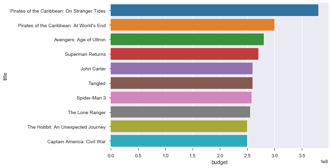

```python
top_10_budget = movies_df.sort_values('budget',ascending=False).head(10)
sns.barplot(x=top_10_budget['budget'],y=top_10_budget['title'])
```

```python
import plotly.express as px
import plotly
fig=px.bar(top_10_budget,x='budget',y='title',orientation='h',color='title')
fig.update_layout(showlegend=False)
fig.show()
```

[interactive chart not shown]

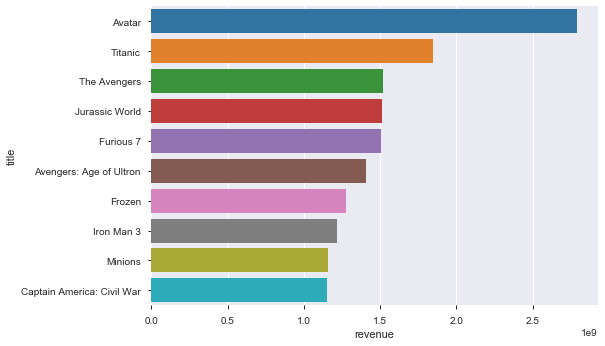

```python
top_10_revenue = movies_df.sort_values('revenue',ascending=False).head(10)
sns.barplot(x=top_10_revenue['revenue'],y=top_10_revenue['title'])
```

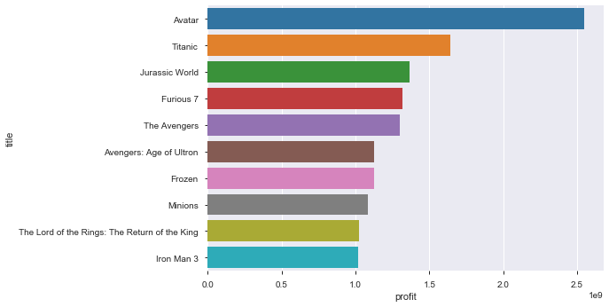

```python
top_10_profit = movies_df.sort_values('profit',ascending=False).head(10)
sns.barplot(x=top_10_profit['profit'],y=top_10_profit['title'])
```

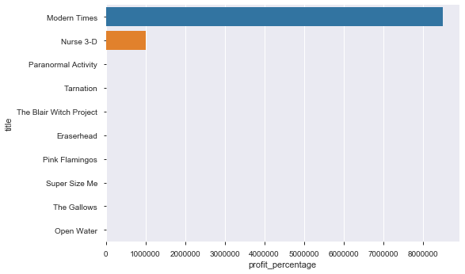

```python
top_10_profit_percentage = movies_df.sort_values('profit_percentage',ascending=False).head(10)
sns.barplot(x=top_10_profit_percentage['profit_percentage'],y=top_10_profit_percentage['title'])
```

loh kok aneh, itu film gimana emang? bisa ga sih fokus ke satu film yang profitnya persentasenya gede banget itu

```python
top_10_profit_percentage[top_10_profit_percentage['title']=='Modern Times'][['title','budget','revenue','profit','profit_percentage']]
```

|  | title | budget | revenue | profit | profit_percentage |
| --- | --- | --- | --- | --- | --- |
| 4238 | Modern Times | 1.0 | 8500000.0 | 8499999.0 | 8499999.0 |

```python
top_10_profit_percentage[['title','budget','revenue','profit','profit_percentage']]
```

|  | title | budget | revenue | profit | profit_percentage |
| --- | --- | --- | --- | --- | --- |
| 4238 | Modern Times | 1.0 | 8500000.0 | 8499999.0 | 8.499999e+06 |
| 3137 | Nurse 3-D | 10.0 | 10000000.0 | 9999990.0 | 9.999990e+05 |
| 4577 | Paranormal Activity | 15000.0 | 193355800.0 | 193340800.0 | 1.288939e+04 |
| 4582 | Tarnation | 218.0 | 1162014.0 | 1161796.0 | 5.329339e+03 |
| 4496 | The Blair Witch Project | 60000.0 | 248000000.0 | 247940000.0 | 4.132333e+03 |
| 4724 | Eraserhead | 10000.0 | 7000000.0 | 6990000.0 | 6.990000e+02 |
| 4788 | Pink Flamingos | 12000.0 | 6000000.0 | 5988000.0 | 4.990000e+02 |
| 4742 | Super Size Me | 65000.0 | 28575078.0 | 28510078.0 | 4.386166e+02 |
| 4723 | The Gallows | 100000.0 | 42664410.0 | 42564410.0 | 4.256441e+02 |
| 4514 | Open Water | 130000.0 | 54667954.0 | 54537954.0 | 4.195227e+02 |

Film ga selamanya untung besar, kadang juga rugi

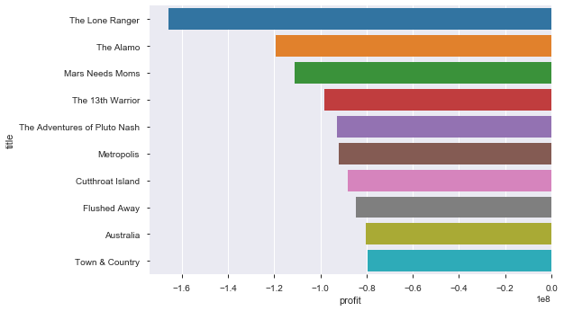

```python
bot_10_profit = movies_df.sort_values('profit').head(10)
sns.barplot(x=bot_10_profit['profit'],y=bot_10_profit['title'])
```

# Visualisasi Interaktif

Visualisasi statis kadang tidak memberikan gambaran besar tentang film yang disajikan, bagaimana karateristik dari film revenue terbesar? hal itu tidak ditampilkan pada bar chart statis  
Oleh karena itu, akan dicoba visualisasi interaktif (dengan plotly)

```python
import plotly
import plotly.express as px
```

Film paling populer?

```python
top_10_popularity = movies_df.sort_values('popularity',ascending=False).head(10)
fig = px.bar(top_10_popularity, x='popularity',y='title',orientation='h',color='title',hover_data=['budget','profit','vote_average','release_year'])
fig.update_layout(showlegend=False,title='Top 10 Movies with Highest Popularity (until 2016)')
fig.show()
```

[interactive chart not shown]

```python
top_10_rating = movies_df.sort_values('vote_average',ascending=False).head(10)
fig = px.bar(top_10_rating, x='vote_average',y='title',orientation='h',color='title',hover_data=['budget','profit','vote_count','release_year'])
fig.update_layout(showlegend=False,title='Top 10 Movies with Highest rating')
fig.show()
```

[interactive chart not shown]

Komentar: perhatikan urutan kedua, baru ada 2 user yang vote film itu, adilkah membandingkan dengan film lainnya?

```python
top_10_rating = movies_df[movies_df['vote_count']>100].sort_values('vote_average',ascending=False).head(10)
fig = px.bar(top_10_rating, x='vote_average',y='title',orientation='h',color='title',hover_data=['budget','profit','vote_count','release_year'])
fig.update_layout(showlegend=False,title='Top 10 Movies with Highest rating')
fig.show()
```

[interactive chart not shown]

Dengan dataset sebesar ini, posibilitas mengeksplor data pun juga sangat luas, contohnya, anda hanya ingin tau film terpopuler di 2016 yang rilis di tahun tersebut (ibaratnya film terpopuler 'tahun ini')

```python
print('Pada tahun 2016 ada: '+str(len(movies_df[movies_df['release_year']==2016]))+' film')
```

```
Pada tahun 2016 ada: 72 film
```

```python
top_10_popularity_2016 = movies_df[movies_df['release_year']==2016].sort_values('popularity',ascending=False).head(10)
fig = px.bar(top_10_popularity_2016, x='popularity',y='title',orientation='h',color='title',hover_data=['budget','profit','vote_average','release_year'])
fig.update_layout(showlegend=False,title='Top 10 Movies with Highest Popularity in 2016')
fig.show()
```

[interactive chart not shown]

Sekarang akan dicoba visualisasi lain selain barplot, misal, kita mau mencari tau  
"Berapa sih rata rata keuntungan film tiap tahunnya?"  
Data yang ada masih rownya menyatakan film (walaupun ada kolom tahunnya), ada baiknya datanya kita ubah dulu menjadi rownya menyatakan tahun (di agregat)

```python
movies_df['release_year'].value_counts().to_frame().reset_index().sort_values('index')
```

|  | index | release_year |
| --- | --- | --- |
| 88 | 1916 | 1 |
| 78 | 1925 | 1 |
| 81 | 1927 | 1 |
| 87 | 1929 | 1 |
| 76 | 1930 | 1 |
| 77 | 1932 | 1 |
| 70 | 1933 | 2 |
| 75 | 1934 | 1 |
| 86 | 1935 | 1 |
| 69 | 1936 | 2 |
| 85 | 1937 | 1 |
| 74 | 1938 | 2 |
| 62 | 1939 | 3 |
| 57 | 1940 | 4 |
| 84 | 1941 | 1 |
| 67 | 1942 | 2 |
| 68 | 1944 | 2 |
| 66 | 1945 | 3 |
| 58 | 1946 | 3 |
| 83 | 1947 | 1 |
| 72 | 1948 | 2 |
| 73 | 1949 | 2 |
| 79 | 1950 | 1 |
| 61 | 1951 | 3 |
| 59 | 1952 | 3 |
| 54 | 1953 | 4 |
| 55 | 1954 | 4 |
| 82 | 1955 | 1 |
| 60 | 1956 | 3 |
| 71 | 1957 | 2 |
| ... | ... | ... |
| 31 | 1987 | 21 |
| 27 | 1988 | 24 |
| 29 | 1989 | 23 |
| 28 | 1990 | 23 |
| 30 | 1991 | 22 |
| 24 | 1992 | 28 |
| 23 | 1993 | 35 |
| 22 | 1994 | 41 |
| 21 | 1995 | 57 |
| 20 | 1996 | 64 |
| 18 | 1997 | 76 |
| 17 | 1998 | 88 |
| 16 | 1999 | 106 |
| 15 | 2000 | 107 |
| 12 | 2001 | 122 |
| 10 | 2002 | 131 |
| 14 | 2003 | 108 |
| 7 | 2004 | 137 |
| 6 | 2005 | 143 |
| 1 | 2006 | 163 |
| 11 | 2007 | 125 |
| 5 | 2008 | 145 |
| 3 | 2009 | 154 |
| 2 | 2010 | 162 |
| 0 | 2011 | 168 |
| 8 | 2012 | 137 |
| 4 | 2013 | 152 |
| 9 | 2014 | 135 |
| 13 | 2015 | 121 |
| 19 | 2016 | 72 |

89 rows × 2 columns

```python
by_year = movies_df.groupby('release_year').mean().reset_index()
by_year
```

|  | release_year | budget | popularity | revenue | runtime | vote_average | vote_count | profit | profit_percentage |
| --- | --- | --- | --- | --- | --- | --- | --- | --- | --- |
| 0 | 1916 | 3.859070e+05 | 3.232447 | 8.394751e+06 | 197.000000 | 7.400000 | 60.000000 | 8.008844e+06 | 2.075330e+01 |
| 1 | 1925 | 2.450000e+05 | 0.785744 | 2.200000e+07 | 151.000000 | 7.000000 | 21.000000 | 2.175500e+07 | 8.879592e+01 |
| 2 | 1927 | 9.262000e+07 | 32.351527 | 6.504220e+05 | 153.000000 | 8.000000 | 657.000000 | -9.196958e+07 | -9.929775e-01 |
| 3 | 1929 | 3.790000e+05 | 0.968865 | 4.358000e+06 | 100.000000 | 5.000000 | 19.000000 | 3.979000e+06 | 1.049868e+01 |
| 4 | 1930 | 3.950000e+06 | 8.484123 | 8.000000e+06 | 127.000000 | 6.100000 | 19.000000 | 4.050000e+06 | 1.025316e+00 |
| 5 | 1932 | 4.000000e+00 | 1.199451 | 2.500000e+01 | 89.000000 | 6.200000 | 28.000000 | 2.100000e+01 | 5.250000e+00 |
| 6 | 1933 | 3.195000e+05 | 1.278059 | 2.240500e+06 | 77.500000 | 5.600000 | 32.000000 | 1.921000e+06 | 7.097950e+00 |
| 7 | 1934 | 3.250000e+05 | 11.871424 | 4.500000e+06 | 105.000000 | 7.700000 | 275.000000 | 4.175000e+06 | 1.284615e+01 |
| 8 | 1935 | 6.090000e+05 | 3.898498 | 3.202000e+06 | 101.000000 | 7.400000 | 59.000000 | 2.593000e+06 | 4.257800e+00 |
| 9 | 1936 | 6.000005e+05 | 15.622357 | 5.618000e+06 | 101.000000 | 7.450000 | 437.000000 | 5.018000e+06 | 4.250000e+06 |
| 10 | 1937 | 1.488423e+06 | 80.171283 | 1.849255e+08 | 83.000000 | 6.900000 | 1914.000000 | 1.834371e+08 | 1.232426e+02 |
| 11 | 1938 | 1.822368e+06 | 1.955144 | 5.716550e+06 | 116.000000 | 6.000000 | 42.500000 | 3.894182e+06 | 2.259664e+00 |
| 12 | 1939 | 2.759000e+06 | 42.887497 | 1.478438e+08 | 156.333333 | 7.666667 | 951.000000 | 1.450848e+08 | 3.853310e+01 |
| 13 | 1940 | 2.042000e+06 | 24.794322 | 4.569800e+07 | 115.250000 | 7.075000 | 626.750000 | 4.365600e+07 | 1.855283e+01 |
| 14 | 1941 | 1.250000e+06 | 7.700190 | 6.000000e+06 | 118.000000 | 6.800000 | 72.000000 | 4.750000e+06 | 3.800000e+00 |
| 15 | 1942 | 8.680000e+05 | 45.690500 | 1.389548e+08 | 86.000000 | 7.350000 | 1413.500000 | 1.380868e+08 | 1.608131e+02 |
| 16 | 1944 | 2.494000e+06 | 0.579747 | 6.127500e+06 | 110.500000 | 6.500000 | 6.000000 | 3.633500e+06 | 1.480297e+00 |
| 17 | 1945 | 1.636667e+06 | 6.076843 | 9.044000e+06 | 110.333333 | 6.833333 | 92.000000 | 7.407333e+06 | 4.898148e+00 |
| 18 | 1946 | 3.760000e+06 | 19.620038 | 1.789804e+07 | 148.666667 | 7.266667 | 418.666667 | 1.413804e+07 | 4.898216e+00 |
| 19 | 1947 | 2.000000e+06 | 5.381536 | 7.800000e+06 | 118.000000 | 6.800000 | 47.000000 | 5.800000e+06 | 2.900000e+00 |
| 20 | 1948 | 3.350000e+06 | 3.125018 | 5.984000e+06 | 117.500000 | 6.950000 | 49.500000 | 2.634000e+06 | 9.014595e-01 |
| 21 | 1949 | 1.300000e+06 | 6.193089 | 6.600000e+06 | 101.500000 | 6.650000 | 47.000000 | 5.300000e+06 | 4.587500e+00 |
| 22 | 1950 | 3.768785e+06 | 1.726175 | 8.000000e+06 | 107.000000 | 7.300000 | 22.000000 | 4.231215e+06 | 1.122700e+00 |
| 23 | 1951 | 4.116667e+06 | 8.154726 | 1.633333e+07 | 134.333333 | 7.166667 | 120.666667 | 1.221667e+07 | 3.287806e+00 |
| 24 | 1952 | 2.423600e+06 | 21.396477 | 1.706667e+07 | 113.333333 | 7.333333 | 370.333333 | 1.464307e+07 | 6.597552e+00 |
| 25 | 1953 | 1.802500e+06 | 5.722932 | 2.000000e+07 | 106.250000 | 6.750000 | 73.750000 | 1.819750e+07 | 1.346872e+01 |
| 26 | 1954 | 3.227500e+06 | 17.302414 | 1.326796e+07 | 145.250000 | 7.250000 | 350.750000 | 1.004046e+07 | 3.831343e+00 |
| 27 | 1955 | 1.200000e+06 | 6.920873 | 7.000000e+06 | 99.000000 | 6.900000 | 149.000000 | 5.800000e+06 | 4.833333e+00 |
| 28 | 1956 | 3.166667e+06 | 2.682735 | 1.126667e+07 | 103.333333 | 6.266667 | 44.000000 | 8.100000e+06 | 3.970370e+00 |
| 29 | 1957 | 1.675000e+06 | 41.184582 | 1.715000e+07 | 128.500000 | 7.950000 | 1310.000000 | 1.547500e+07 | 5.978571e+00 |
| ... | ... | ... | ... | ... | ... | ... | ... | ... | ... |
| 59 | 1987 | 1.704286e+07 | 23.047969 | 7.415863e+07 | 106.476190 | 6.433333 | 588.952381 | 5.711577e+07 | 4.560306e+00 |
| 60 | 1988 | 1.347500e+07 | 21.604397 | 6.805015e+07 | 105.708333 | 6.437500 | 598.208333 | 5.457515e+07 | 3.704872e+00 |
| 61 | 1989 | 2.187217e+07 | 23.263152 | 1.167821e+08 | 112.304348 | 6.634783 | 815.565217 | 9.490997e+07 | 6.421603e+00 |
| 62 | 1990 | 3.173913e+07 | 29.857563 | 1.679901e+08 | 117.260870 | 6.573913 | 1176.043478 | 1.362510e+08 | 6.313802e+00 |
| 63 | 1991 | 3.038636e+07 | 21.424517 | 1.210958e+08 | 116.090909 | 6.377273 | 755.136364 | 9.070943e+07 | 2.733170e+00 |
| 64 | 1992 | 2.670091e+07 | 28.418482 | 1.322735e+08 | 113.500000 | 6.575000 | 811.035714 | 1.055726e+08 | 5.146577e+00 |
| 65 | 1993 | 2.298286e+07 | 21.242472 | 1.101986e+08 | 113.257143 | 6.465714 | 679.742857 | 8.721579e+07 | 3.190531e+00 |
| 66 | 1994 | 3.115188e+07 | 31.009460 | 1.443840e+08 | 113.292683 | 6.473171 | 1223.365854 | 1.132322e+08 | 7.604454e+00 |
| 67 | 1995 | 3.542719e+07 | 23.757418 | 1.067255e+08 | 114.982456 | 6.345614 | 775.947368 | 7.129832e+07 | 2.447169e+00 |
| 68 | 1996 | 3.790769e+07 | 19.731779 | 1.058347e+08 | 111.921875 | 6.189062 | 523.203125 | 6.792703e+07 | 2.278955e+00 |
| 69 | 1997 | 4.594628e+07 | 25.007476 | 1.256499e+08 | 115.657895 | 6.381579 | 815.960526 | 7.970359e+07 | 3.248007e+00 |
| 70 | 1998 | 4.052432e+07 | 21.292036 | 9.341992e+07 | 109.704545 | 6.315909 | 647.750000 | 5.289560e+07 | 1.891869e+00 |
| 71 | 1999 | 4.008420e+07 | 21.113482 | 9.727172e+07 | 109.877358 | 6.296226 | 721.679245 | 5.718751e+07 | 4.075598e+01 |
| 72 | 2000 | 4.418411e+07 | 19.940352 | 1.021526e+08 | 110.186916 | 6.131776 | 672.971963 | 5.796851e+07 | 1.650305e+00 |
| 73 | 2001 | 4.290382e+07 | 22.525629 | 1.082836e+08 | 108.721311 | 6.169672 | 828.795082 | 6.537974e+07 | 1.897485e+00 |
| 74 | 2002 | 4.140496e+07 | 23.901353 | 1.112666e+08 | 107.236641 | 6.190840 | 749.793893 | 6.986163e+07 | 2.548175e+00 |
| 75 | 2003 | 4.633808e+07 | 27.448167 | 1.309825e+08 | 109.740741 | 6.185185 | 908.638889 | 8.464443e+07 | 5.170840e+01 |
| 76 | 2004 | 4.431349e+07 | 26.072608 | 1.166806e+08 | 108.854015 | 6.248175 | 904.664234 | 7.236714e+07 | 1.011664e+01 |
| 77 | 2005 | 4.275898e+07 | 22.254919 | 1.040133e+08 | 109.615385 | 6.207692 | 696.783217 | 6.125430e+07 | 2.021831e+00 |
| 78 | 2006 | 3.967319e+07 | 22.468154 | 1.001999e+08 | 109.490798 | 6.226994 | 749.055215 | 6.052672e+07 | 2.698169e+00 |
| 79 | 2007 | 4.510262e+07 | 25.351078 | 1.287140e+08 | 108.680000 | 6.347200 | 904.096000 | 8.361142e+07 | 1.060888e+02 |
| 80 | 2008 | 4.715103e+07 | 28.153164 | 1.236488e+08 | 107.020690 | 6.166207 | 963.165517 | 7.649776e+07 | 2.102223e+00 |
| 81 | 2009 | 4.631349e+07 | 27.235357 | 1.359110e+08 | 107.357143 | 6.250649 | 1018.993506 | 8.959750e+07 | 1.570835e+00 |
| 82 | 2010 | 4.585414e+07 | 27.235477 | 1.250508e+08 | 107.901235 | 6.201852 | 1056.370370 | 7.919671e+07 | 2.672974e+00 |
| 83 | 2011 | 4.495503e+07 | 27.018290 | 1.217931e+08 | 106.720238 | 6.132738 | 1001.404762 | 7.683809e+07 | 2.712925e+00 |
| 84 | 2012 | 5.189104e+07 | 35.457552 | 1.735361e+08 | 107.452555 | 6.191241 | 1619.145985 | 1.216450e+08 | 3.484905e+00 |
| 85 | 2013 | 5.233151e+07 | 38.388110 | 1.522739e+08 | 111.388158 | 6.344737 | 1628.572368 | 9.994237e+07 | 6.581437e+03 |
| 86 | 2014 | 5.198148e+07 | 61.606583 | 1.781277e+08 | 111.177778 | 6.340741 | 1765.792593 | 1.261462e+08 | 3.083913e+00 |
| 87 | 2015 | 5.284711e+07 | 63.293609 | 1.857632e+08 | 112.355372 | 6.259504 | 1690.347107 | 1.329160e+08 | 6.786067e+00 |
| 88 | 2016 | 6.379708e+07 | 51.806021 | 2.007115e+08 | 111.069444 | 6.119444 | 1630.555556 | 1.369144e+08 | 2.750501e+00 |

89 rows × 9 columns

## Apakah film makin kesini makin lama? atau makin sebentar?

```python
px.line(by_year,y='runtime',x='release_year')
```

[interactive chart not shown]

## Apakah kualitas film makin kesini makin disukai?

```python
px.line(by_year,y='vote_average',x='release_year')
```

[interactive chart not shown]

### Bagaimana dengan keuntungan film?

```python
px.line(by_year,y='profit',x='release_year')
```

[interactive chart not shown]

### Bagaimana jika kita mau menampilkan 2 buah garis? atau lebih?

Perlu diperhatikan bahwa plot interaktif oleh plotly, dapat memisahkan garis berdasarkan kategori tertentu, misal kita mau menggambarkan budget dan revenue dalam satu plot, kita harus punya kategori yang menyatakan dia nilai dari budget atau revenue?  
Bagaimana cara membuatnya?

## Pengenalan Pivot Table & Melt Table

[figure not shown]

```python
by_year_melted = pd.melt(by_year[['release_year','budget','revenue']],
        id_vars=['release_year'],
        value_vars=['budget','revenue'],
       var_name='tipe',
       value_name='nilai')
```

```python
px.line(by_year_melted,x='release_year',y='nilai',color='tipe')
```

[interactive chart not shown]

### Bagaimana kalau kita mau menampilkan persebaran sebenarnya? bukan rata rata? disinilah boxplot ataupun ekstensinya (violinplot) berperan

```python
px.box(movies_df[movies_df['release_year']>=2010],x='release_year',y='profit',color='release_year',hover_name='title')
```

[interactive chart not shown]

```python
px.violin(movies_df[movies_df['release_year']>=2010],x='release_year',y='profit',hover_name='title')
```

[interactive chart not shown]